# RFMによる顧客管理

## 2019/01

本資料はOBS授業「ビジネスデータ分析」の第７回授業「顧客管理のためのデータ分析」を補足するものです。使用しているサンプルデータファイル"RFM.csv"は照井伸彦・佐藤忠彦『現代マーケティングリサーチ』所載のデータです。。但し、分析作業は原著者とは関係なく、西山が行ったことをお断りしておきます。

```r
dir()
```

1. 'RFM.csv'

2. 'Untitled.ipynb'

```r
rfm <- read.csv(file="RFM.csv")
```

デーファイルを読み込んだ後、まずは**要約**して大雑把にデータの中身をみておくが**鉄則**です。

```r
dim(rfm) # 行数と列数を確認
summary(rfm)　# 要約する
```

1. 2000

2. 5

```
    Customer            M                F               R            DM
 Min.   :   1.0   Min.   :   467   Min.   : 1.00   Min.   :  1.00   no :1279
 1st Qu.: 500.8   1st Qu.:141747   1st Qu.: 6.00   1st Qu.: 20.75   yes: 721
 Median :1000.5   Median :274411   Median :12.00   Median : 41.00
 Mean   :1000.5   Mean   :276496   Mean   :12.81   Mean   : 55.22
 3rd Qu.:1500.2   3rd Qu.:418265   3rd Qu.:18.00   3rd Qu.: 74.00
 Max.   :2000.0   Max.   :549795   Max.   :40.00   Max.   :229.00
```

数量データR, F, Mについてはヒストグラムもみておく。これを習慣づけましょう。

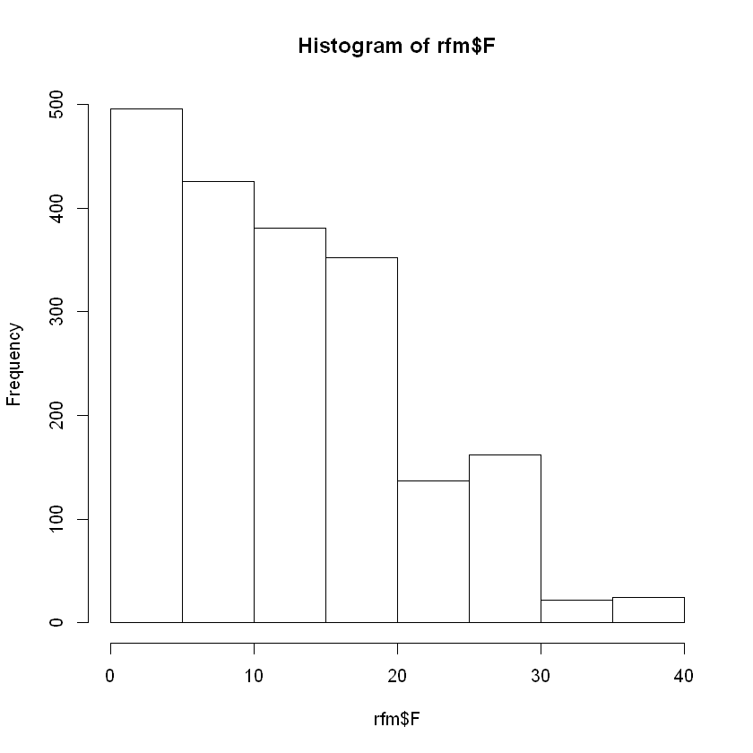

```r
hist(rfm$F)
```

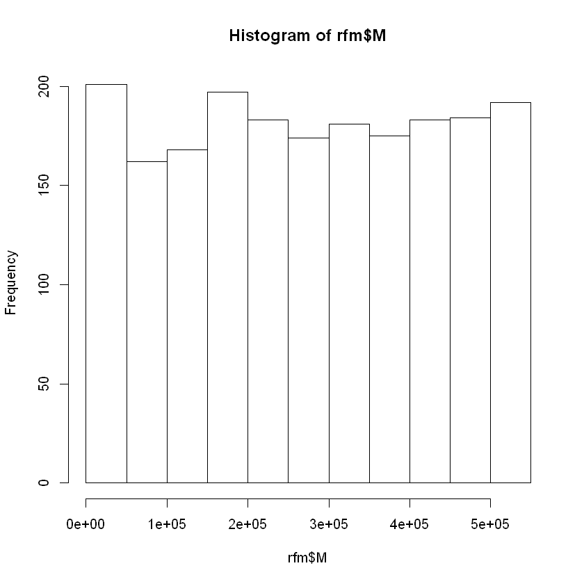

```r
hist(rfm$M)
```

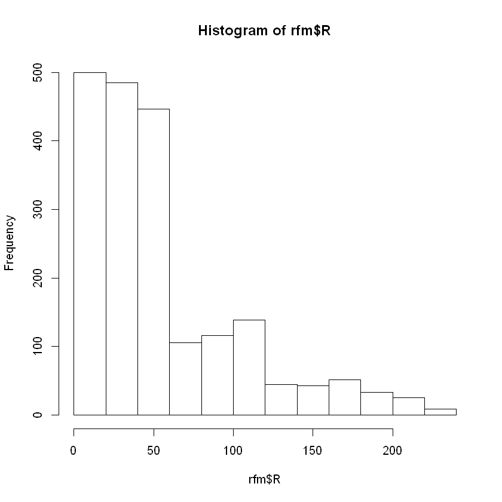

```r
hist(rfm$R)
```

## ５分位分析（デシル分析の簡単版）

変数R, F, Mはそれぞれ「直近来店時からの経過日数」、「累積来店回数」、「累積購買金額」であり、CRMのための基本三因子として活用されるようになってきています。まずはシンプルなデータ活用法である10分位分析（デシル分析）、但しこの資料ではレコード数が2000人と比較的少数のため5分位分析を行ってみることにします。

それには、F,M,Rそれぞれを大小順に並べてから、同じ人数ずつ5つのクラスにわけます。2000人を400人ずつ5つのクラスに分けたうえ、クラスには"F1"から"F5"、"M1"から"M5"、"R1"から"R5"のように名前をつけることにします。元の数量データをその大きさに従って区分し、クラスに名前をつけるわけですから行うことは数値から分類カテゴリーへの変換です。そのためこのような作業を**カテゴリー化**と言います。

カテゴリー化には"cut"コマンドを使います。クラス名を値とする新たな質的変数は分類のための因子（＝ファクター）になります。

```r
qt <- quantile(rfm$F, probs = c(0,0.2,0.4,0.6,0.8,1))
rankF <- cut(rfm$F, breaks = qt, labels = c("F1", "F2", "F3", "F4", "F5"), include.lowest = TRUE)
```

```r
class(rankF)
length(rankF)
rfm$F[1:20]
rankF[1:20]
table(rankF)
```

'factor'

2000

1. 6

2. 4

3. 15

4. 30

5. 12

6. 4

7. 6

8. 15

9. 4

10. 13

11. 19

12. 24

13. 17

14. 25

15. 3

16. 3

17. 11

18. 8

19. 14

20. 24

1. F2

2. F1

3. F4

4. F5

5. F3

6. F1

7. F2

8. F4

9. F1

10. F3

11. F4

12. F5

13. F4

14. F5

15. F1

16. F1

17. F3

18. F2

19. F3

20. F5

**Levels**:**

1. 'F1'

2. 'F2'

3. 'F3'

4. 'F4'

5. 'F5'

```
rankF
 F1  F2  F3  F4  F5
496 334 389 436 345
```

同じ値は同じクラスに入るため、値が小数ではなく、整数で値が重複する人が多い場合は、正確に400人ずつのクラスにはなりません。とはいえ、分析に困ることはありません。下の、累積購買金額は1円単位で値が入力されているということもあって、400人ずつのクラスができました。

```r
qt <- quantile(rfm$M, probs = c(0,0.2,0.4,0.6,0.8,1))
rankM <- cut(rfm$M, breaks = qt, labels = c("M1", "M2", "M3", "M4", "M5"), include.lowest = TRUE)
length(rankM)
table(rankM)
```

2000

```
rankM
 M1  M2  M3  M4  M5
400 400 400 400 400
```

```r
qt <- quantile(rfm$R, probs = c(0,0.2,0.4,0.6,0.8,1))
rankR <- cut(rfm$R, breaks = qt, labels = c("R5", "R4", "R3", "R2", "R1"), include.lowest = TRUE)
length(rankR)
table(rankR)
```

2000

```
rankR
 R5  R4  R3  R2  R1
400 419 387 395 399
```

```r
library(ggplot2) # グラフ作成の定番パッケージです。もしこのコマンドでエラーが出る場合、インストールして下さい。
```

累積来店回数（F)の箱ひげ図をrankFで層別化して作成すると、以下のようになります。クラスが最下位の"F1"からより上位のクラスへ移るごとに来店回数が増えていることが再確認できます。

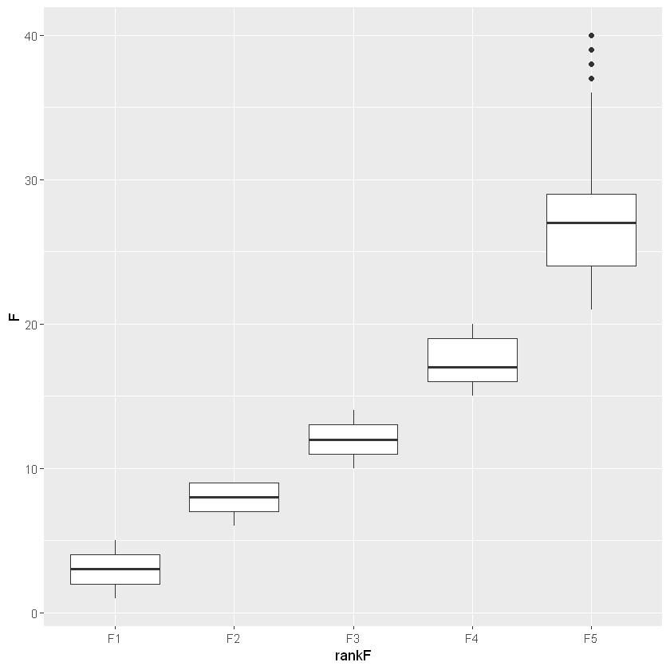

```r
ggplot(rfm, aes(x=rankF, y=F)) + geom_boxplot()
```

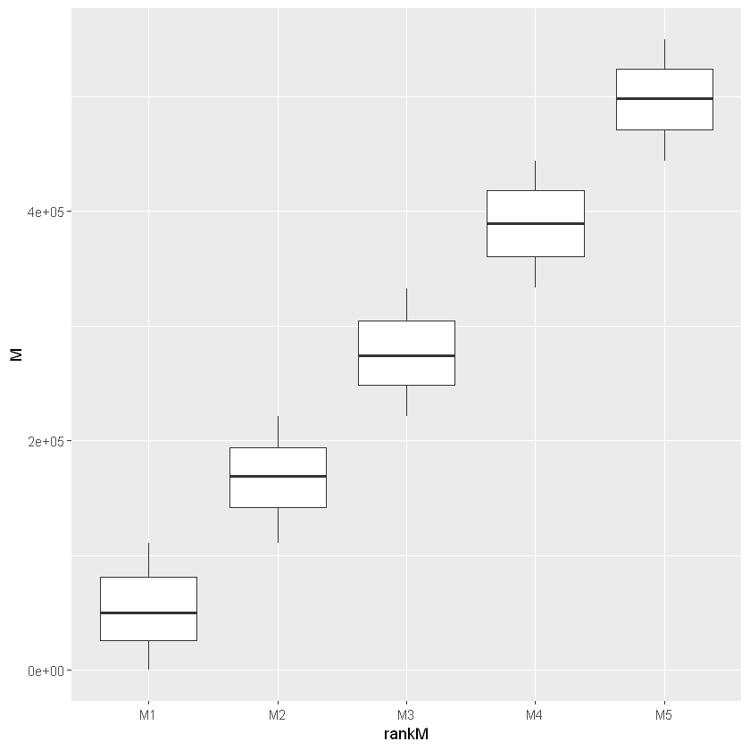

```r
ggplot(rfm, aes(x=rankM, y=M)) + geom_boxplot()
```

直近来店時からの経過日数（R)については最も経過日数が少ないクラスを高く評価して"R5"としている点に注意の事。

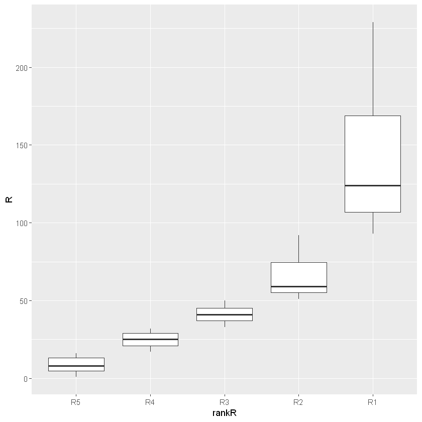

```r
ggplot(rfm, aes(x=rankR, y=R)) + geom_boxplot()
```

Rコマンダーでは数値変数を区分したときのクラス名は自動的に同じデータセットに追加されましたが、コマンドで操作しているときは、新しく作った変数が自動的にどこかに追加されることはありません。Rコマンダーで「データセット」というのは、実は「データフレーム(data.frame)」と呼ばれるタイプの変数ですが、データフレームに新しくデータを追加するときは以下のようにします。

```r
rfm <- data.frame(rfm, rankF, rankM, rankR) # 同じ長さ（行数）の表やデータを一つにまとめる
class(rfm)
head(rfm) # 最初の何行かをみたいときは"head"コマンドを使う
```

'data.frame'

| Customer | M | F | R | DM | rankF | rankM | rankR |
| --- | --- | --- | --- | --- | --- | --- | --- |
| 1 | 311349 | 6 | 6 | yes | F2 | M3 | R5 |
| 2 | 509794 | 4 | 28 | yes | F1 | M5 | R4 |
| 3 | 176331 | 15 | 51 | yes | F4 | M2 | R2 |
| 4 | 402413 | 30 | 33 | yes | F5 | M4 | R3 |
| 5 | 16689 | 12 | 4 | no | F3 | M1 | R5 |
| 6 | 263978 | 4 | 126 | no | F1 | M3 | R1 |

## 来店回数と購買金額で優良顧客を選び出す

```r
goodF <- subset(rfm, subset = (rankF=="F5"|rankF=="F4")) # 行や列を取り出すときはエクセルよりRのほうが遥かに効率的
dim(goodF)
head(goodF,10)
```

1. 781

2. 8

|  | Customer | M | F | R | DM | rankF | rankM | rankR |
| --- | --- | --- | --- | --- | --- | --- | --- | --- |
| 3 | 3 | 176331 | 15 | 51 | yes | F4 | M2 | R2 |
| 4 | 4 | 402413 | 30 | 33 | yes | F5 | M4 | R3 |
| 8 | 8 | 125001 | 15 | 35 | no | F4 | M2 | R3 |
| 11 | 11 | 219339 | 19 | 50 | yes | F4 | M2 | R3 |
| 12 | 12 | 418277 | 24 | 4 | yes | F5 | M4 | R5 |
| 13 | 13 | 191852 | 17 | 58 | yes | F4 | M2 | R2 |
| 14 | 14 | 325230 | 25 | 20 | no | F5 | M3 | R4 |
| 20 | 20 | 468018 | 24 | 46 | yes | F5 | M5 | R3 |
| 23 | 23 | 312326 | 26 | 4 | yes | F5 | M3 | R5 |
| 24 | 24 | 522631 | 34 | 25 | yes | F5 | M5 | R4 |

```r
goodFM <- subset(goodF, subset = (rankM=="M5"|rankM=="M4")) # 来店回数（F)で上位層を取り出した後、購買金額（M)の上位層を抽出する
dim(goodFM)
head(goodFM,10)
```

1. 457

2. 8

|  | Customer | M | F | R | DM | rankF | rankM | rankR |
| --- | --- | --- | --- | --- | --- | --- | --- | --- |
| 4 | 4 | 402413 | 30 | 33 | yes | F5 | M4 | R3 |
| 12 | 12 | 418277 | 24 | 4 | yes | F5 | M4 | R5 |
| 20 | 20 | 468018 | 24 | 46 | yes | F5 | M5 | R3 |
| 24 | 24 | 522631 | 34 | 25 | yes | F5 | M5 | R4 |
| 26 | 26 | 440905 | 20 | 34 | yes | F4 | M4 | R3 |
| 27 | 27 | 515250 | 34 | 21 | yes | F5 | M5 | R4 |
| 32 | 32 | 498366 | 23 | 13 | yes | F5 | M5 | R5 |
| 35 | 35 | 495402 | 26 | 54 | no | F5 | M5 | R2 |
| 43 | 43 | 547412 | 31 | 27 | yes | F5 | M5 | R4 |
| 45 | 45 | 472860 | 22 | 23 | no | F5 | M5 | R4 |

```r
summary(goodFM) # rankF, rankMを確認のこと
```

```
    Customer            M                F               R           DM
 Min.   :   4.0   Min.   :333292   Min.   :15.00   Min.   : 1.00   no :118
 1st Qu.: 512.0   1st Qu.:397427   1st Qu.:19.00   1st Qu.:14.00   yes:339
 Median : 951.0   Median :452068   Median :24.00   Median :27.00
 Mean   : 998.3   Mean   :448627   Mean   :24.08   Mean   :27.95
 3rd Qu.:1490.0   3rd Qu.:504388   3rd Qu.:28.00   3rd Qu.:41.00
 Max.   :2000.0   Max.   :549795   Max.   :40.00   Max.   :60.00
 rankF    rankM    rankR
 F1:  0   M1:  0   R5:132
 F2:  0   M2:  0   R4:148
 F3:  0   M3:  0   R3:116
 F4:149   M4:211   R2: 61
 F5:308   M5:246   R1:  0
```

## ロジステッィク回帰分析で予測モデル―全データ

```r
model1 <- glm(DM ~ F + M + R, family=binomial(link="logit"), data=rfm)
```

```r
summary(model1)
```

```
Call:
glm(formula = DM ~ F + M + R, family = binomial(link = "logit"),
    data = rfm)

Deviance Residuals:
    Min       1Q   Median       3Q      Max
-2.5349  -0.7560  -0.3634   0.7937   2.7024

Coefficients:
              Estimate Std. Error z value Pr(>|z|)
(Intercept) -2.193e+00  1.857e-01 -11.810  < 2e-16 ***
F            9.488e-02  8.553e-03  11.093  < 2e-16 ***
M            3.505e-06  3.900e-07   8.987  < 2e-16 ***
R           -1.580e-02  2.014e-03  -7.845 4.32e-15 ***
---
Signif. codes:  0 '***' 0.001 '**' 0.01 '*' 0.05 '.' 0.1 ' ' 1

(Dispersion parameter for binomial family taken to be 1)

    Null deviance: 2614.8  on 1999  degrees of freedom
Residual deviance: 1910.5  on 1996  degrees of freedom
AIC: 1918.5

Number of Fisher Scoring iterations: 5
```

```r
exp(model1$coefficients) # オッズ比に与える効果
```

**(Intercept)**

0.111547047975851

**F**

1.09952569904098

**M**

1.00000350517782

**R**

0.984324046246374

```r
rfm$prob <- model1$fitted.values
summary(rfm$prob)
```

```
    Min.  1st Qu.   Median     Mean  3rd Qu.     Max.
0.003957 0.120302 0.308469 0.360500 0.570401 0.966078
```

ダイレクトメールに反応する確率がどう分布しているかをグラフにします。

実際には反応している人は3人に1人程度ですから、反応確率の山はかなり低い所にあります。しかし、あまり得る所は多くはない図であるのも事実ですね(^^;;)

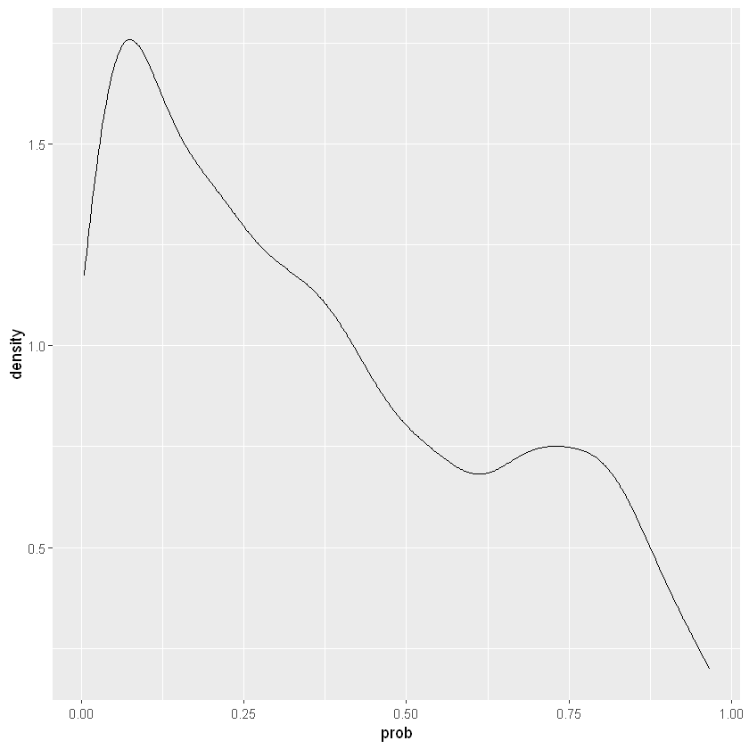

```r
ggplot(rfm, aes(x=prob)) + geom_line(stat="density")
```

ロジステッィク回帰分析の計算結果をみても、係数の大きさから察しはつくのですが、こうしてグラフに見える化する手法の方をおすすめしなす。

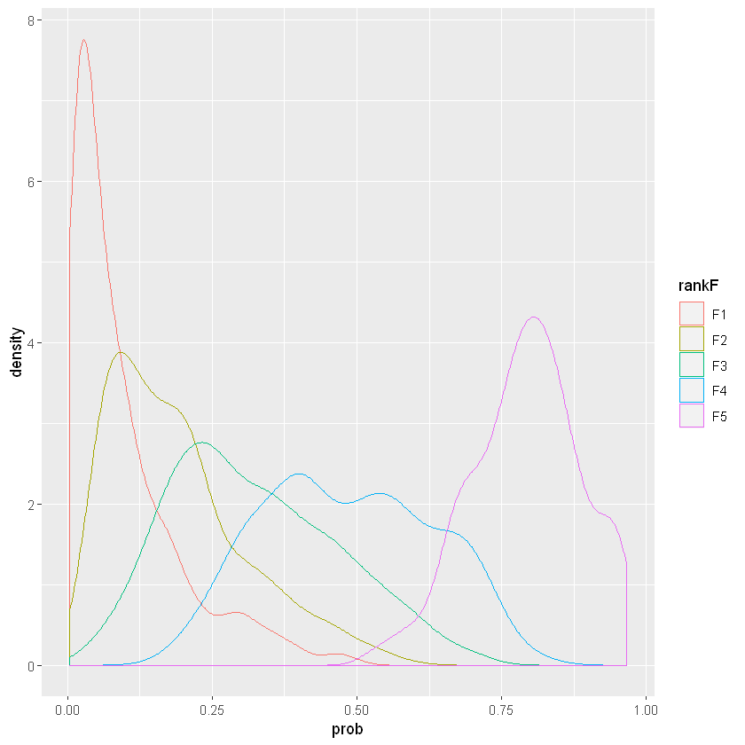

```r
ggplot(rfm, aes(x=prob, color=rankF)) + geom_density()
```

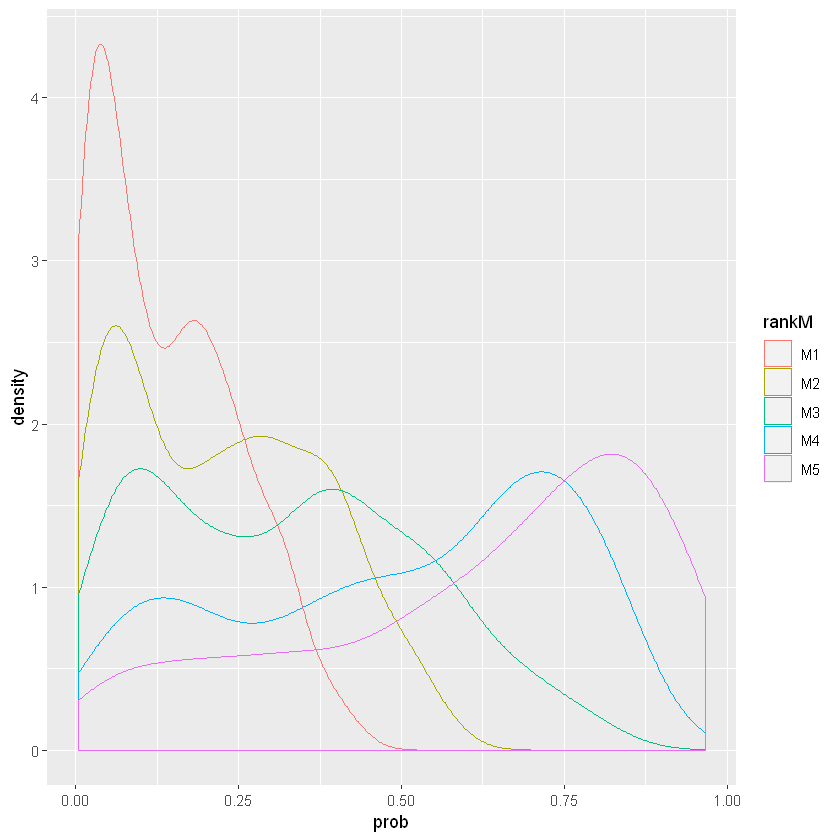

```r
ggplot(rfm, aes(x=prob, color=rankM)) + geom_density()
```

累積購買金額（M)も反応確率に影響することが上の図をみればわかります。それに対して、直近来店時から経過日数は、特に"R3", "R4", "R5"の分布図が重なっています。ということは、経過日数はクーポンへの反応にほとんど影響がないということです。ただ、”R1"クラスだけは来店する可能性がほとんどないことがハッキリしていいます。

経過日数については、クラス"R1"に含まれるかどうかだけが重要だと言えそうです。

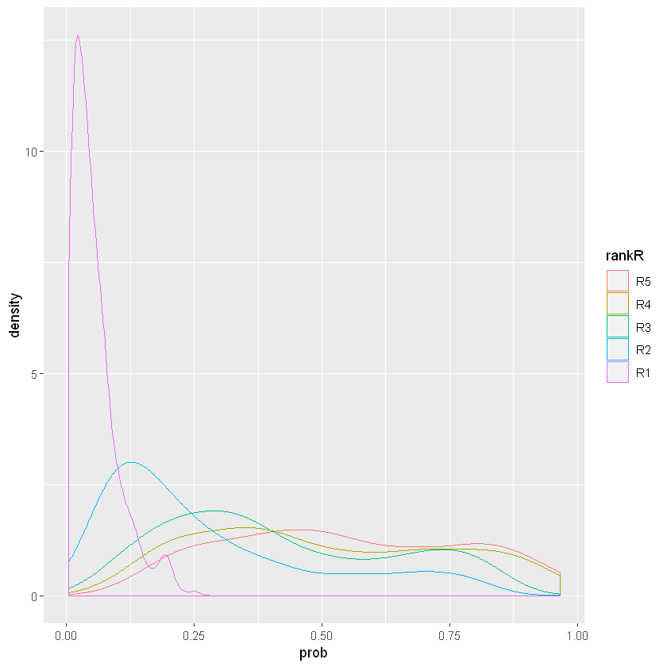

```r
ggplot(rfm, aes(x=prob, color=rankR)) + geom_density()
```

一応、経過日数で最も下位にある"R1"は、具体的にどの程度の日数がたっている客なのか？この点だけを確かめておきましょう。

```r
summary(subset(rfm, rankR == "R1"))
```

```
    Customer            M                F                R           DM
 Min.   :   6.0   Min.   :   467   Min.   : 1.000   Min.   : 93.0   no :372
 1st Qu.: 477.0   1st Qu.: 89613   1st Qu.: 2.000   1st Qu.:107.0   yes: 27
 Median : 961.0   Median :196858   Median : 4.000   Median :124.0
 Mean   : 971.3   Mean   :221939   Mean   : 4.323   Mean   :138.3
 3rd Qu.:1482.5   3rd Qu.:336870   3rd Qu.: 6.000   3rd Qu.:169.0
 Max.   :1999.0   Max.   :549734   Max.   :10.000   Max.   :229.0
 rankF    rankM    rankR         prob
 F1:287   M1:118   R5:  0   Min.   :0.003957
 F2: 91   M2:101   R4:  0   1st Qu.:0.021265
 F3: 21   M3: 78   R3:  0   Median :0.041787
 F4:  0   M4: 55   R2:  0   Mean   :0.054865
 F5:  0   M5: 47   R1:399   3rd Qu.:0.073996
                            Max.   :0.250402
```

上のコマンドの意味は、データセット"rfm"からrankRの値が"R1"である行（＝客）だけを抜き取り（subsetコマンド）、その後で要約をする（summaryコマンド）ものです。

これを見ると、経過日数が93日以上になっています（最大は229日経過）。要するに、最後に来てから3か月以上たっている顧客はダイレクトメールにまずは反応しない。そう予測してもよい。前回ダイレクトメールへの反応実績に基づく限り、こんな見込みがたちそうです。

## ロジステッィク回帰分析で予測モデル―通常作業

顧客行動の予測モデルを作成する際には、通常、データ全体を推定に使用する**トレーニングデータ**と予測能力の評価に使う**テストデータ**の二つに分割しています。多くの場合、テスト用に使うデータ割合は10％を目安にしても問題はないと思われます。ここでは全データ2000人からランダムに200人をテスト用に留保し、残りの1800人を予測モデル作成に使うことにします。

テスト用のデータセットを抜き取る方法には複数のやり方がありますが、ここでは最も単純な方法、即ち1から2000までの整数を乱順に並べ替えたうえで、最初の200行をテスト用に、残りをトレーニング用のデータとします。それには"sample"コマンドが便利でしょう。例えば、1から10までの整数を並べ替えるには以下のようにします。

```r
sample(1:10,10)
```

1. 8

2. 3

3. 9

4. 2

5. 7

6. 5

7. 10

8. 1

9. 4

10. 6

```r
idx <- sample(1:2000, 2000) # 1から2000までを乱順に並べる
test.id <- idx[1:200] # 最初の200個を保存
train.id <- idx[201:2000] #　残りの1800個の数字を保存
test <- rfm[test.id, ] # データセット"rfm"からtest.idで保存された行番号をとりだす
train <- rfm[train.id, ] # 残りの1800行をとりだす
```

データ全体をスプリットした時点で、トレーニングデータとテストデータの要約を見ておきます。

以下に見るとおり、RFMの各種属性、反応確率、ダイレクトメールへの反応割合とも概ね同じになっているので、二つのグループの傾向は同じであると判定できます。

```r
dim(train)
summary(train)
```

1. 1800

2. 9

```
    Customer            M                F               R            DM
 Min.   :   1.0   Min.   :   467   Min.   : 1.00   Min.   :  1.00   no :1150
 1st Qu.: 497.8   1st Qu.:141314   1st Qu.: 6.00   1st Qu.: 21.00   yes: 650
 Median :1002.5   Median :274027   Median :12.00   Median : 41.00
 Mean   :1001.5   Mean   :276910   Mean   :12.88   Mean   : 55.63
 3rd Qu.:1504.2   3rd Qu.:418892   3rd Qu.:18.00   3rd Qu.: 74.00
 Max.   :2000.0   Max.   :549795   Max.   :40.00   Max.   :229.00
 rankF    rankM    rankR         prob
 F1:444   M1:362   R5:348   Min.   :0.003957
 F2:293   M2:360   R4:377   1st Qu.:0.121722
 F3:359   M3:358   R3:354   Median :0.307142
 F4:387   M4:357   R2:360   Mean   :0.361090
 F5:317   M5:363   R1:361   3rd Qu.:0.569246
                            Max.   :0.966078
```

```r
dim(test)
summary(test)
```

1. 200

2. 9

```
    Customer            M                F              R            DM
 Min.   :   5.0   Min.   :   859   Min.   : 1.0   Min.   :  2.00   no :129
 1st Qu.: 528.8   1st Qu.:145913   1st Qu.: 5.0   1st Qu.: 16.00   yes: 71
 Median : 979.5   Median :278066   Median :11.0   Median : 36.00
 Mean   : 991.9   Mean   :272769   Mean   :12.2   Mean   : 51.58
 3rd Qu.:1480.0   3rd Qu.:390242   3rd Qu.:18.0   3rd Qu.: 70.75
 Max.   :1992.0   Max.   :547893   Max.   :40.0   Max.   :210.00
 rankF   rankM   rankR        prob
 F1:52   M1:38   R5:52   Min.   :0.005692
 F2:41   M2:40   R4:42   1st Qu.:0.117959
 F3:30   M3:42   R3:33   Median :0.321232
 F4:49   M4:43   R2:35   Mean   :0.355195
 F5:28   M5:37   R1:38   3rd Qu.:0.577342
                         Max.   :0.965618
```

まずトレーニング用のデータで行動予測モデルを作成し、その予測モデルを計算には含めなかったテストデータに適用して結果を予測することにします。テストデータについても、実際の行動やYesかNoで分かっていますから、予測された行動と実際の行動を比べることによって予測精度を評価することができます。

```r
model2 <- glm(DM ~ F + M + R, family=binomial(link="logit"), data=train)
```

```r
summary(model2)
```

```
Call:
glm(formula = DM ~ F + M + R, family = binomial(link = "logit"),
    data = train)

Deviance Residuals:
    Min       1Q   Median       3Q      Max
-2.5407  -0.7436  -0.3586   0.7767   2.7074

Coefficients:
              Estimate Std. Error z value Pr(>|z|)
(Intercept) -2.236e+00  1.969e-01 -11.359  < 2e-16 ***
F            9.296e-02  8.971e-03  10.363  < 2e-16 ***
M            3.744e-06  4.125e-07   9.075  < 2e-16 ***
R           -1.581e-02  2.115e-03  -7.474 7.81e-14 ***
---
Signif. codes:  0 '***' 0.001 '**' 0.01 '*' 0.05 '.' 0.1 ' ' 1

(Dispersion parameter for binomial family taken to be 1)

    Null deviance: 2354.6  on 1799  degrees of freedom
Residual deviance: 1710.9  on 1796  degrees of freedom
AIC: 1718.9

Number of Fisher Scoring iterations: 5
```

```r
exp(model2$coefficients)
```

**(Intercept)**

0.10684102419449

**F**

1.09742209696712

**M**

1.00000374381559

**R**

0.984315890865993

（当然であるとも言えるのですが）上の結果"model1"と同様の結果が出ています。テストデータも概ね同じ傾向を示していますから、この予測モデルを適用しても問題はないはずです － ただし、テストデータに含まれる個々の顧客は上の予測モデル作成には使ってはいないことに注意してください。

```r
pred <- predict(model2, newdata=test, type="response") # テストデータについて反応確率を求める
```

```r
length(pred) # 計算に含めなかった新規200人について反応確率が計算された
```

200

```r
yn.yosoku <- ifelse(pred > 0.5, "Y", "N") # 確率が0.5を超える人は"Y"、0.5未満の人は"N"とする
yn.yosoku <- as.factor(yn.yosoku)　# "Y", "N"の文字を分類のための因子（ファクター）にしておく
```

```r
summary(yn.yosoku)
```

**N**

139

**Y**

61

```r
tbl <- table(yn.yosoku, test$DM) # テストデータに含まれる200人の実際の行動を説明変数R,F,Mから正しく予測できたかを表にする
tbl
```

```
yn.yosoku  no yes
        N 110  29
        Y  19  42
```

```r
(tbl[1,1]+tbl[2,2])/(sum(tbl))　# 全体としては76％の人を正しく予測できている　➡　この指標を「精度」といいます
```

0.76

```r
tbl[2,2]/sum(tbl[2,])　# 「反応するだろう」と予測した人の69％は実際に反応しています　➡　この指標を「適合率」といいます
```

0.688524590163934

```r
tbl[2,2]/sum(tbl[,2])　#　実際に反応した人の59％は、事前に「反応するだろう」と予測できていました　➡　この指標を「再現率」といいます
```

0.591549295774648

注： 全データを用いた時の結果"model1"の精度についてはホームワークにしておきましょう。授業を履修した方はパワーポイントに記載しています。